# Introduction to computational social science, notation, and functions

[Computational Mathematics and Statistics Camp](https://github.com/math-camp/course) University of Chicago September 2018

## Why we are here

- Social science
  - Anthropology
  - Economics
  - History
  - Political science
  - Psychology
  - Sociology
  - Comparative human development(?)

## Computational social science

- Computational approaches to the social sciences
- Historic definition
- Modern definition
  - [Intersection of computer science, math/statistics, and social science](http://science.sciencemag.org.proxy.uchicago.edu/content/323/5915/721.full)

## Computational social science

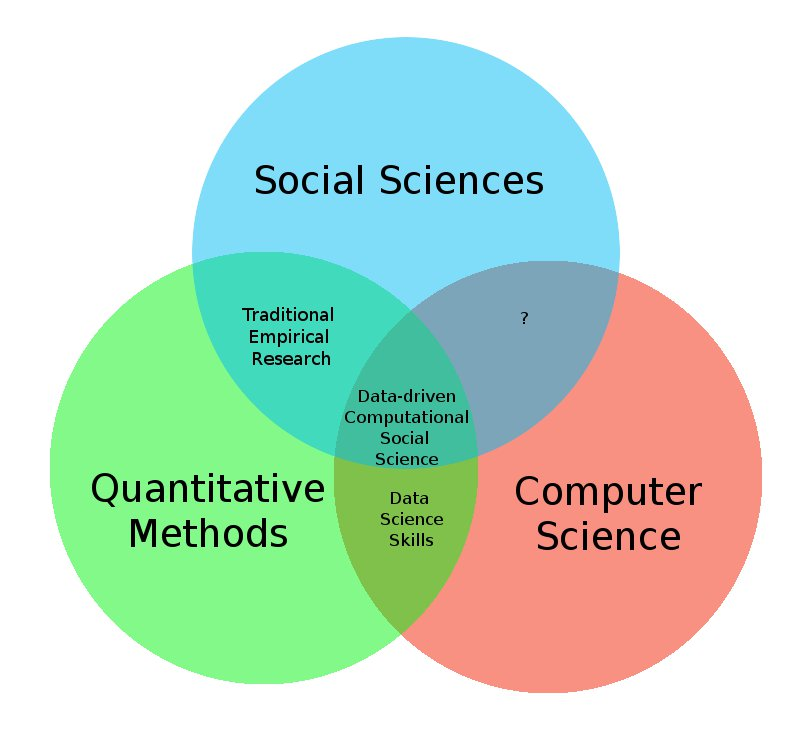

## Acquiring CSS skills

- Computer science
- Social science
- Math/statistics

## Mathematics

- Purely abstract
- Based on axioms that are independent from the real world
- If the axioms are accepted, mathematical inferences are certain
- Language for expressing structure and relationships
- Generally proof-based

## Probability

- Systematic and rigorous method for treating uncertainty
- “Mathematical models of uncertain reality”
- Derivation of “applied mathematics”

## Statistics

- Practice or science of collecting and analyzing numerical data in large quantities, especially for the purpose of inferring proportions in a whole from those in a sample
- Making inferences from data that are not entirely certain
- Based on mathematical models, but with deviations from the model (not deterministic)

## Their uses

- Mathematical models
  - Game theory
  - Formal theory
  - Much bigger in economics
  - Defining statistical models and relationships
- Probability/statistics
  - Establishing a structure for relationships between variables using data
  - Inferring relationships and assessing their validity

## Goals for the camp

- Computational **Mathematics** and **Statistics** Camp
- Survey math and statistical tools that are foundational to CSS
- Review common mathematical notation
- Apply math/statistics methods
- Prepare students to pass the MACSS math/stats placement exam

## Course logistics

> All course materials are located on [GitHub](https://github.com/math-camp/course)

## Course staff

- Me
- Teaching assistants
  - Sanja Miklin
  - Nora Nickels

## Prerequisites

- No formal prerequisites
- Most likely to succeed
  - Linear algebra
  - Calculus
  - Probability theory
  - Statistical inference
- Assume prior exposure

## Alternatives to this camp

- SOSC 30100 - Mathematics for Social Sciences (aka the Hansen math camp)
- MACS 30100 - Mathematics and Statistics for Computational Social Science
- Departmental methods sequences
- Math/stats departments

## Evaluation

- Pass/fail (no credit)
- Grades no longer matter (or should not)
- Learn as much material as possible
- **If you truly only care about learning material, you’ll get amazing grades**

## Pedagogical approach

- Flipped-classroom design
- Instructional staff is to be your “sherpa” and guide you along your journey

[Comment](https://www.reddit.com/r/AskReddit/comments/9anxn8/kids_in_school_used_to_say_well_never_need_to/e4x4j3a/) from discussion [Kids in school used to say “We’ll never need to know this in the real world”. What, in your experience, were they wrong about?](https://www.reddit.com/r/AskReddit/comments/9anxn8/kids_in_school_used_to_say_well_never_need_to/).

## Computational tools for the future

- Vision is open-source
- Shift away from proprietary formats (e.g. SPSS, Stata, SAS)
- Emphasis on **reproducibility**
  - Code
  - Results
  - Analysis
  - Publication

## Programming languages

[figure not shown]

## Programming languages

- Python
- R
- Things R does well
  - Statistical analysis
  - Data visualization
- Things R does not do as well
  - Speed
- Things Python does well
  - General computation
  - Speed
  - The [Jupyter Notebook](http://jupyter.org/)
- Things Python does not do as well
  - Visualizations
  - Add-on libraries

## Version control

- Revisions in research
- Tracking revisions
- Multiple copies
  - `analysis-1.r`
  - `analysis-2.r`
  - `analysis-3.r`
- Cloud storage (e.g. Dropbox, Google Drive, Box)
- Version control software
  - Repository
  - **Git**

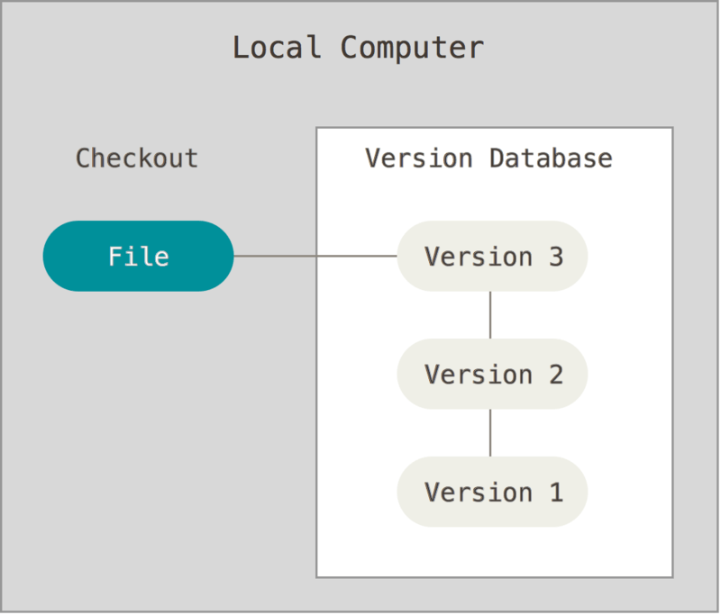

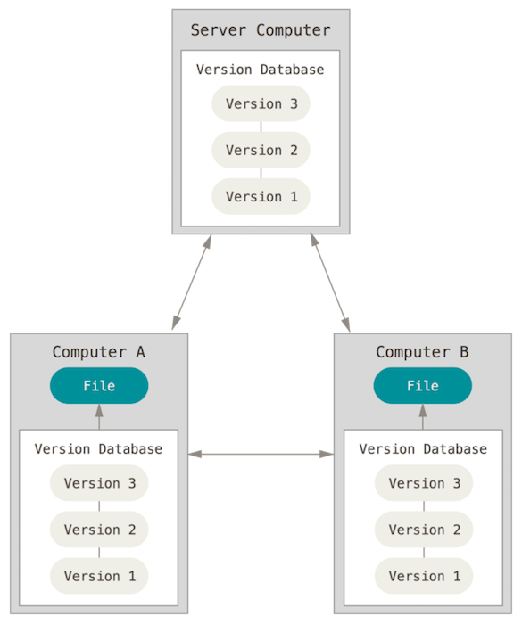

## Move away from WYSIWYG

- What You See Is What You Get
- Microsoft Word or Google Docs
- Not a reproducible format

## Notebooks

- Integrate code, output, and written text
- Reproducible
  - Rerun the notebook to regenerate all the output
- Good for prototyping and exploratory data analysis
- For Python - Jupyter Notebooks
- For R - R Markdown

## $\LaTeX$

- High-quality typesetting system
- De facto standard for production of technical and scientific documentation
- Free software
- Renders documents as PDFs
- Makes typesetting easy

  ```
  $$f(x) = \frac{\exp(-\frac{(x - \mu)^2}{2\sigma^2} )}{ \sqrt{2\pi \sigma^2}}$$
  ```

  $$f(x) = \frac{\exp(-\frac{(x - \mu)^2}{2\sigma^2} )}{ \sqrt{2\pi \sigma^2}}$$
- Tables/figures/general typesetting/nice presentations - easier in $\LaTeX$
- Steep learning curve up front, but leads to big dividends later

## Markdown

- Lightweight markup language with plain text formatting syntax
- Easy to convert to HTML, PDF, and more
- Used commonly on GitHub documentation, Jupyter Notebooks, R Markdown, and more
- Simplified syntax compared to $\LaTeX$ - also less flexibility
- Publishing formats

## How you will acquire these skills

> Irony - you won’t learn any of that here. No time to teach programming AND math AND statistics in 3 weeks.
- Python
- R
- Git
- $\LaTeX$/Markdown/notebooks

## Why is math important to social science

- Consistent language to communicate ideas in an orderly and systematic way
- Science uses highly precise language that is not easily interpretable to outsiders
- Mathematics is an effective way to describe our world
- Mathematical notation lets us convey **precision** and minimizes the risk of misinterpretation by other scholars

## Example: Rational voter theory

- Rational voters should weigh the rewards vs. costs of voting
- Mathematical notation

  $$R = PB - C$$
  - $R =$ the utility satisfaction of voting
  - $P =$ the actual probability that the voter will affect the outcome with her particular vote
  - $B =$ the perceived difference in benefits between the two candidates measured in **utiles** (units of utility)
  - $C =$ the actual cost of voting in utiles (e.g. time, effort, money)
- Does the model seem reasonable?
- What implications does the model provide?

## Example: Rational voter theory

[output not shown]

- Leads to the **paradox of voting**
- Clearly a question worth answering in political science
- Pure mathematical model may not be fully accurate, but allows us to delve deeper into the paradox

## Equations

- An equation “equates” two quantities - they are arithmetically identical
  - $R = PB - C$
  - $R$ and $PB - C$ are exactly equal to one another
- Equations do not need to be equalities
  - Greater than/less than
  - Approximately equal

## Functions

- A mapping which gives a correspondence from one measure onto exactly one other for that value
- Mapping from one defined space to another, such as $f \colon \Re \rightarrow \Re$

  $$f(x) = x^2 - 1$$
  - Maps $x$ to $f(x)$ by squaring $x$ and subtracting 1

## Not a function

- All functions are relations, but not all relations are functions
- Functions have exactly one value returned by $f(x)$ for each value of $x$
- Relations may have more than one value returned

## Not a function

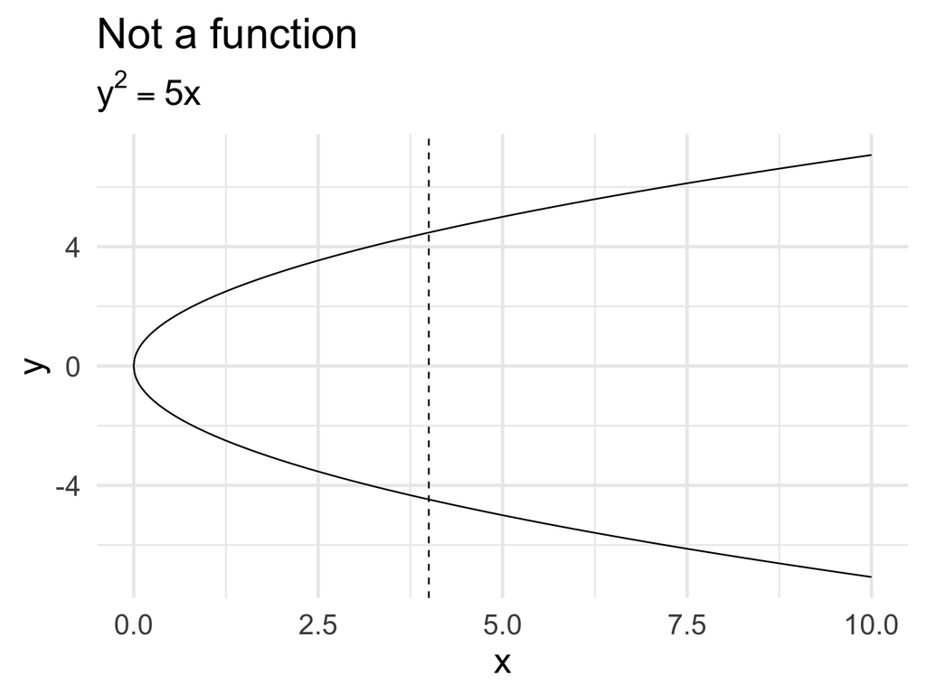

## Not a function

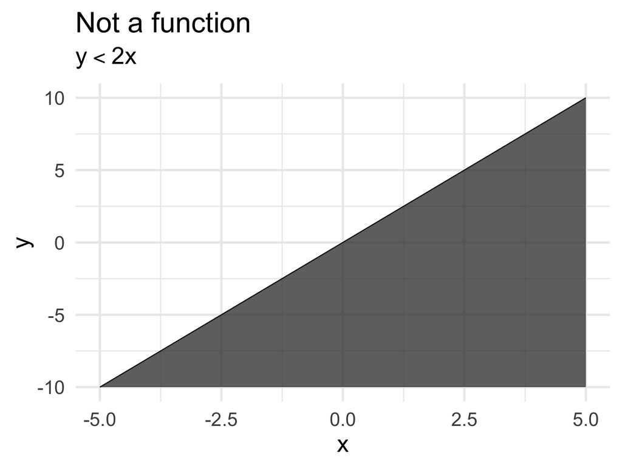

## Two major properties of functions

$$f(x) = y$$

1. Continuous
2. Invertible

   $$g^{-1}(y) = x, \text{where } g^{-1}(g(x)) = x$$

## Not all functions are continuous and invertible

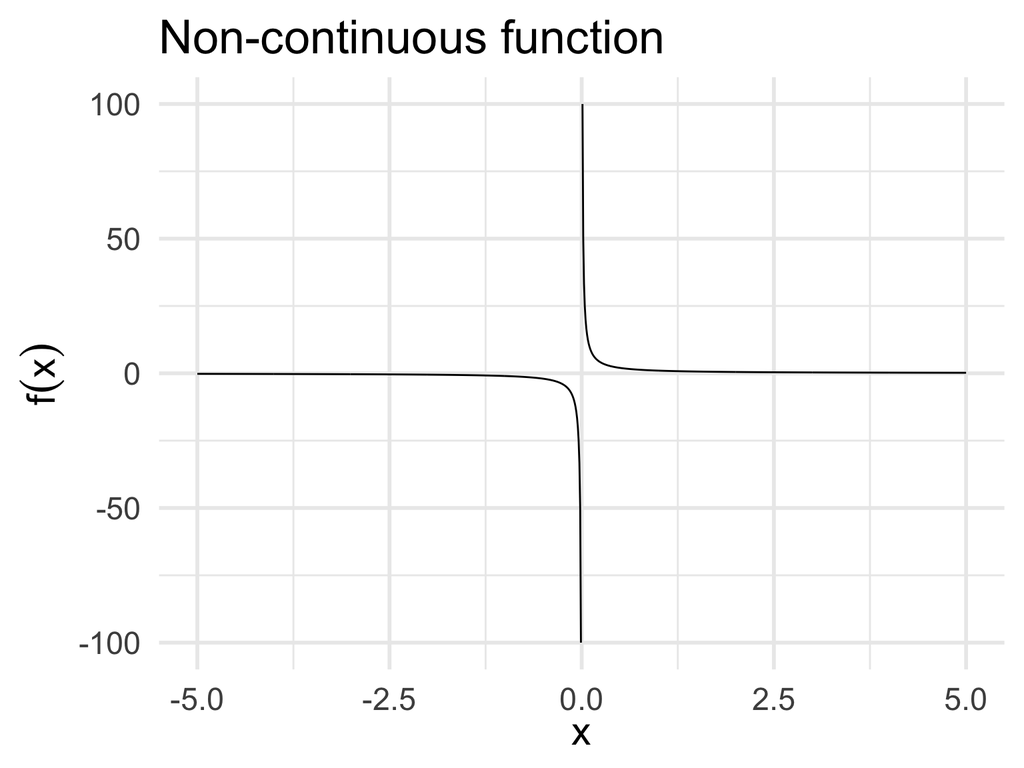

## Not all functions are continuous and invertible

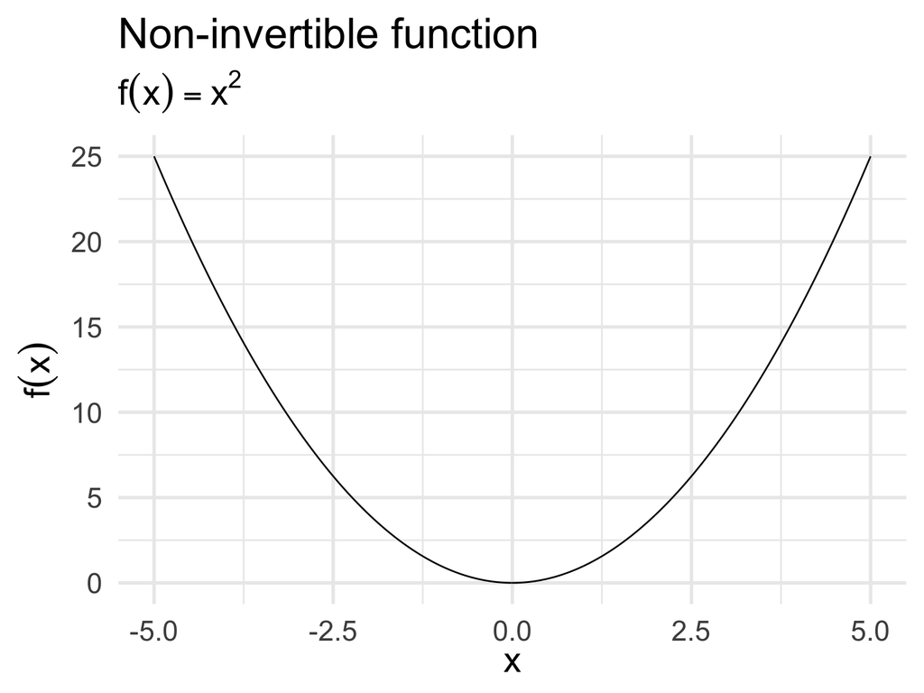

## Not all functions are continuous and invertible

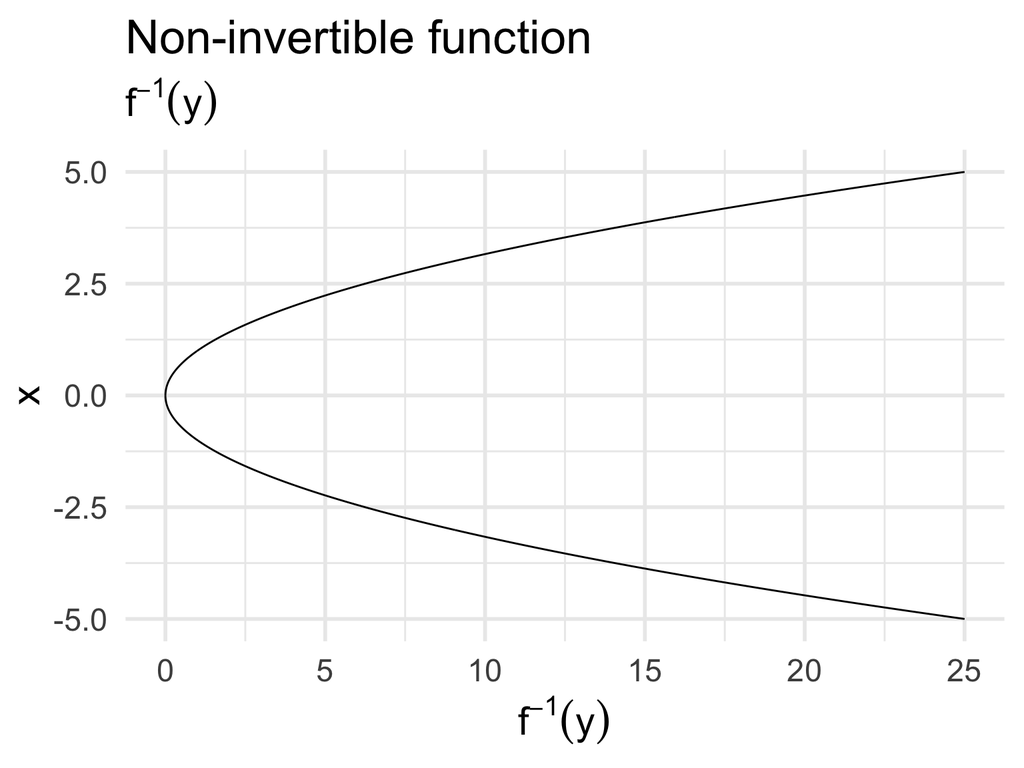

## Why this is important

- Functions must be continuous AND invertible to calculate derivatives in calculus
- Important for optimization and solving for parameter values in modeling strategies
- Non-continuous functions - cannot do much about
- Non-invertible functions
  - Can make invertible by restricting the **domain**

## Restrict the domain

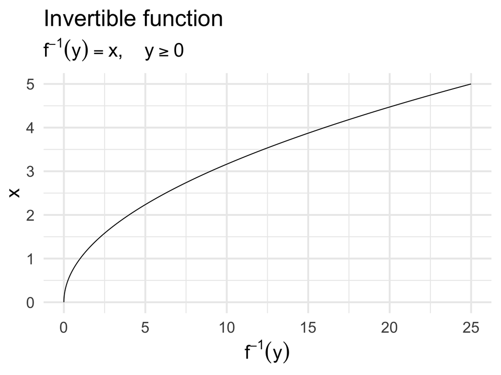

## Logarithms and exponents

- Important component to many mathematical and statistical methods in social science
- Exponents - repeatedy multiply a number by itself
- Logarithms - reverse of an exponent

## Common rules of exponents

- $x^0 = 1$
- $x^1 = x$
- $\left ( \frac{x}{y} \right )^a = \left ( \frac{x^a}{y^a}\right ) = x^a y^{-a}$
- $(x^a)^b = x^{ab}$
- $(xy)^a = x^a y^a$
- $x^a \times x^b = x^{a+b}$

## Logarithms

- Class of functions
  - $\log_{b}(x) = a \Rightarrow b^a = x$
  - What number $a$ solves $b^a = x$
- Commonly used bases
  - Base 10

    $$\log_{10}(100) = 2 \Rightarrow 10^2 = 100$$

    $$\log_{10}(0.1) = -1 \Rightarrow 10^{-1} = 0.1$$
  - Base 2

    $$\log_{2}(8) = 3 \Rightarrow 2^3 = 8$$

    $$\log_{2}(1) = 0 \Rightarrow 2^0 = 1$$

## Logarithms

- Base $e$ - Euler’s number (aka a **natural logarithm**)

  $$\log_{e}(e) = 1 \Rightarrow e^1 = e$$
  - Natural logarithms are incredibly useful in math
  - Often $\log()$ is assumed to be a natural log
  - Also seen as $\ln()$
- Rules of logarithms
  - $\log_b(1) = 0$
  - $\log(x \times y) = \log(x) + \log(y)$
  - $\log(\frac{x}{y}) = \log(x) - \log(y)$
  - $\log(x^y) = y \log(x)$